# Analisis Estadistico de Datos

Grupo 05

I-2025

# Trabajo Final

**Arboles de Decision - Clasificacion**  
**Maestría en Energías Renovables**  
**Escuela de Ingeniería, Ciencia y Tecnología**  
**Universidad del Rosario**  
**Integrantes:**  
Zahira Itzel González Cleves  
Diego Alejandro Mejía Montañez  
Daniel Felipe Russi Aragón  
Iván Camilo Granados Niño  
Andrés Alfonso Osorio Marulanda

## Exploracion y Preparacion de Datos

A continuacion se presentan una pequeña porcion de los [datos](https://www.kaggle.com/datasets/yasserh/wine-quality-dataset?resource=download) contenidos en el dataset a fin de conocer mejor las variables

```r
str(df_wineQ01)
```

```
## 'data.frame':    1143 obs. of  13 variables:
##  $ fixed.acidity       : num  7.4 7.8 7.8 11.2 7.4 7.4 7.9 7.3 7.8 6.7 ...
##  $ volatile.acidity    : num  0.7 0.88 0.76 0.28 0.7 0.66 0.6 0.65 0.58 0.58 ...
##  $ citric.acid         : num  0 0 0.04 0.56 0 0 0.06 0 0.02 0.08 ...
##  $ residual.sugar      : num  1.9 2.6 2.3 1.9 1.9 1.8 1.6 1.2 2 1.8 ...
##  $ chlorides           : num  0.076 0.098 0.092 0.075 0.076 0.075 0.069 0.065 0.073 0.097 ...
##  $ free.sulfur.dioxide : num  11 25 15 17 11 13 15 15 9 15 ...
##  $ total.sulfur.dioxide: num  34 67 54 60 34 40 59 21 18 65 ...
##  $ density             : num  0.998 0.997 0.997 0.998 0.998 ...
##  $ pH                  : num  3.51 3.2 3.26 3.16 3.51 3.51 3.3 3.39 3.36 3.28 ...
##  $ sulphates           : num  0.56 0.68 0.65 0.58 0.56 0.56 0.46 0.47 0.57 0.54 ...
##  $ alcohol             : num  9.4 9.8 9.8 9.8 9.4 9.4 9.4 10 9.5 9.2 ...
##  $ quality             : int  5 5 5 6 5 5 5 7 7 5 ...
##  $ Id                  : int  0 1 2 3 4 5 6 7 8 10 ...
```

Se realiza la transformacion de la matriz y se grafican los histogramas de cada variable para lograr un mayor entendimiento de estas:

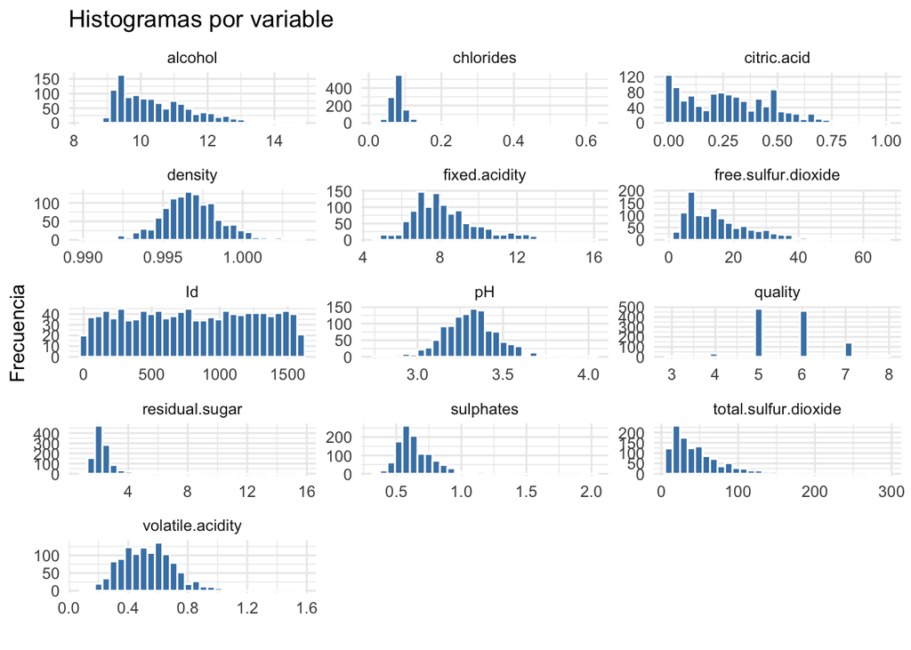

```r
df_wineQ01_long <- df_wineQ01 %>%
  pivot_longer(cols = where(is.numeric), names_to = "Variable", values_to = "Valor")

ggplot(df_wineQ01_long, aes(x = Valor)) +
  geom_histogram(fill = "steelblue", color = "white", bins = 30) +
  facet_wrap(~ Variable, scales = "free", ncol = 3) +
  theme_minimal() +
  labs(title = "Histogramas por variable",
       x = "", y = "Frecuencia")
```

Se calculan tambien algunos estadisticos de las variables para aumentar la comprension de los datos que se presentan a continuacion:

```r
# Estadísticos descriptivos
resumen01 <- psych::describe(df_wineQ01)

# Mostrar tabla formateada
kable(resumen01, caption = "Resumen descriptivo de Variables Vino 01", digits = 2)
```

Resumen descriptivo de Variables Vino 01

|  | vars | n | mean | sd | median | trimmed | mad | min | max | range | skew | kurtosis | se |
| --- | --- | --- | --- | --- | --- | --- | --- | --- | --- | --- | --- | --- | --- |
| fixed.acidity | 1 | 1143 | 8.31 | 1.75 | 7.90 | 8.13 | 1.33 | 4.60 | 15.90 | 11.30 | 1.04 | 1.37 | 0.05 |
| volatile.acidity | 2 | 1143 | 0.53 | 0.18 | 0.52 | 0.52 | 0.18 | 0.12 | 1.58 | 1.46 | 0.68 | 1.36 | 0.01 |
| citric.acid | 3 | 1143 | 0.27 | 0.20 | 0.25 | 0.26 | 0.25 | 0.00 | 1.00 | 1.00 | 0.37 | -0.72 | 0.01 |
| residual.sugar | 4 | 1143 | 2.53 | 1.36 | 2.20 | 2.26 | 0.44 | 0.90 | 15.50 | 14.60 | 4.35 | 27.50 | 0.04 |
| chlorides | 5 | 1143 | 0.09 | 0.05 | 0.08 | 0.08 | 0.01 | 0.01 | 0.61 | 0.60 | 6.01 | 46.78 | 0.00 |
| free.sulfur.dioxide | 6 | 1143 | 15.62 | 10.25 | 13.00 | 14.34 | 8.90 | 1.00 | 68.00 | 67.00 | 1.23 | 1.91 | 0.30 |
| total.sulfur.dioxide | 7 | 1143 | 45.91 | 32.78 | 37.00 | 41.20 | 26.69 | 6.00 | 289.00 | 283.00 | 1.66 | 5.06 | 0.97 |
| density | 8 | 1143 | 1.00 | 0.00 | 1.00 | 1.00 | 0.00 | 0.99 | 1.00 | 0.01 | 0.10 | 0.87 | 0.00 |
| pH | 9 | 1143 | 3.31 | 0.16 | 3.31 | 3.31 | 0.15 | 2.74 | 4.01 | 1.27 | 0.22 | 0.91 | 0.00 |
| sulphates | 10 | 1143 | 0.66 | 0.17 | 0.62 | 0.64 | 0.12 | 0.33 | 2.00 | 1.67 | 2.49 | 11.93 | 0.01 |
| alcohol | 11 | 1143 | 10.44 | 1.08 | 10.20 | 10.33 | 1.04 | 8.40 | 14.90 | 6.50 | 0.86 | 0.21 | 0.03 |
| quality | 12 | 1143 | 5.66 | 0.81 | 6.00 | 5.60 | 1.48 | 3.00 | 8.00 | 5.00 | 0.29 | 0.30 | 0.02 |
| Id | 13 | 1143 | 804.97 | 464.00 | 794.00 | 805.90 | 596.01 | 0.00 | 1597.00 | 1597.00 | -0.01 | -1.22 | 13.72 |

Se procede ahora a preparar el conjunto de datos para el analisis de arbol, se transforma la variable `quality` en factor para que el metodo `rpart` la interprete adecuadamente:

```r
df_wine <- df_wineQ01 %>%
  dplyr::select(-Id) %>% # Quita la columna 'Id' (la columna de identificación)
  dplyr::mutate(quality = as.factor(quality)) # Convierte la columna 'quality' a tipo factor
```

Ahora, se crealos conjuntos de entrenamiento, validación y pruebas de forma aleatoria; se deja una semilla (seed) para que sea reproducible la simulacion. Cada conjunto se define con una cantidad fija de registros; 65.5% aprox. para el conjunto de entrenamiento, 26.5% para validacion y 8% para pruebas:

```r
set.seed(1234)

# Definicion conjunto de Entrenamiento (Train)
wineQ_train <- sample_n(df_wine, 750)

# Definicion conjunto de Validacion (Validation)
wineQ_valdtn <- sample_n(df_wine, 300)

# Definicion conjunto de Prueba (Test)
wineQ_test <- sample_n(df_wine, 93)
```

## Entrenamiento y Prueba del Modelo

Una vez definidos los conjuntos de datos, se procede a entrenar el modelo con el conjunto de datos haciendo uso de la funcion `rpart` y el mayor de los 3 conjuntos de datos (Conjunto de Entrenamiento):

```r
arbolWineTrn <- rpart(quality ~ ., data=wineQ_train, method="class")
arbolWineTrn
```

```
## n= 750
##
## node), split, n, loss, yval, (yprob)
##       * denotes terminal node
##
##  1) root 750 438 5 (0.0053 0.029 0.42 0.4 0.13 0.019)
##    2) alcohol< 10.35 393 148 5 (0.01 0.033 0.62 0.3 0.028 0.0051)
##      4) sulphates< 0.585 184  43 5 (0.011 0.038 0.77 0.18 0 0) *
##      5) sulphates>=0.585 209 105 5 (0.0096 0.029 0.5 0.4 0.053 0.0096)
##       10) total.sulfur.dioxide>=28.5 133  53 5 (0 0.038 0.6 0.31 0.045 0.0075)
##         20) alcohol< 9.85 99  30 5 (0 0.04 0.7 0.23 0.02 0.01) *
##         21) alcohol>=9.85 34  16 6 (0 0.029 0.32 0.53 0.12 0) *
##       11) total.sulfur.dioxide< 28.5 76  33 6 (0.026 0.013 0.32 0.57 0.066 0.013)
##         22) volatile.acidity>=0.655 13   4 5 (0.077 0.077 0.69 0.15 0 0) *
##         23) volatile.acidity< 0.655 63  22 6 (0.016 0 0.24 0.65 0.079 0.016) *
##    3) alcohol>=10.35 357 174 6 (0 0.025 0.19 0.51 0.24 0.034)
##      6) sulphates< 0.675 207  88 6 (0 0.043 0.25 0.57 0.12 0.014) *
##      7) sulphates>=0.675 150  86 6 (0 0 0.11 0.43 0.41 0.06)
##       14) alcohol< 11.85 113  55 6 (0 0 0.13 0.51 0.32 0.035)
##         28) volatile.acidity>=0.315 88  38 6 (0 0 0.16 0.57 0.24 0.034) *
##         29) volatile.acidity< 0.315 25  10 7 (0 0 0.04 0.32 0.6 0.04)
##           58) fixed.acidity< 8.35 7   1 6 (0 0 0 0.86 0.14 0) *
##           59) fixed.acidity>=8.35 18   4 7 (0 0 0.056 0.11 0.78 0.056) *
##       15) alcohol>=11.85 37  12 7 (0 0 0.027 0.16 0.68 0.14) *
```

Como resultado del anterior fragmento de codigo, se observa el esquema de arbol de clasificacion obtenido, en donde cada linea presenta los resultados de cada uno de los nodos y la regla de clasificacion correspondiente. Por ejemplo para la linea 2), que indica alli `2) alcohol< 10.35 393 148 5 (0.01 0.033 0.62 0.3 0.028 0.0051)`, indica que el criterio de decision del arbol es si el alcohol que contiene el vino es menor que 10.35 ($Alcohol<10.35$), que de los 750 registros del conjunto de entrenamiento **393** cumplen con este criterio y de ellos la categoria dominante es la **5** con un 62%, finalmente se presenta en parentesis los porcentajes de todas categorias.

Complementando lo anterior en para la linea 3), que indica `3) alcohol>=10.35 357 174 6 (0 0.025 0.19 0.51 0.24 0.034)` el criterio de decision complemente el del punto 2), es decir, si el nivel alcohol que contiene el vino es mayor o igual a 10.35 ($Alcohol\geqslant10.35$) con **357** registros que cumplen el criterio del conjunto de datos y de ellos la categoria dominante es la **6** con un 51%. Con esto, y tomando como referencia los histogramas presentados al inicio de las categorias, se logra segmentar las categorias dominnantes del conjunto total de datos.

El resultado visual del arbol (esquema) se presenta a continuación:

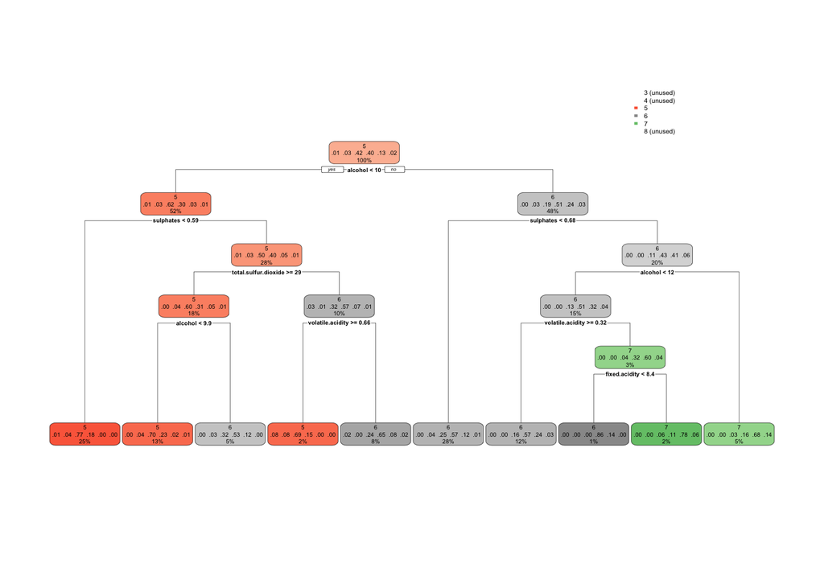

```r
rpart.plot(arbolWineTrn)
```

De dicha imagen, en cada nodo se evidencian 3 lineas de numeros congruentes con lo indicado en parrafos anteriores:

- **1er nivel:** etiqueta, categoria o Variable de Clasificacion, en el dataset `quiality` (Tipo Factor) que tiene el mayor porcentaje de todas las definidas para el modelo.
- **2o nivel:** proporcion de los registros del conjunto de datos de cada categoria conforme a la segmentacion hecha en el nodo.
- **3r nivel:** porcentaje del total del conjunto de los datosque que se concentra en el nodo.

Una vez, con el modelo definido, se procede a realizar la prediccion con la funcion `predict` haciendo uso del conjunto de validación.

```r
arbolPrediccion_01 <- predict(arbolWineTrn, newdata=wineQ_valdtn, type="class")
#A continuacion las primeras 10 predicciones del modelo
head(arbolPrediccion_01, 10)
```

```
##  1  2  3  4  5  6  7  8  9 10
##  6  6  6  5  5  6  6  6  6  6
## Levels: 3 4 5 6 7 8
```

```r
#A continuacion las primeras 10 predicciones del modelo\n")
head(wineQ_valdtn[["quality"]], 10)
```

```
##  [1] 6 6 5 5 6 5 5 5 5 6
## Levels: 3 4 5 6 7 8
```

Tomando los resultados de la predicción, y comparado estos con los datos del conjunto de validacion, se evidencian diferencias entre los primeros 10 registros de ambos conjuntos.

Luego, se procede a realizar el analisis de los resultados comparando los datos de la prediccion con los datos reales del conjunto de validacion generando la matriz de confusion con base en las referencias de la siguiente imagen

```r
confusionMatrix(arbolPrediccion_01, wineQ_valdtn[["quality"]])
```

```
## Confusion Matrix and Statistics
##
##           Reference
## Prediction  3  4  5  6  7  8
##          3  0  0  0  0  0  0
##          4  0  0  0  0  0  0
##          5  1  8 96 20  0  0
##          6  0  4 45 81 18  2
##          7  0  0  0  8 15  2
##          8  0  0  0  0  0  0
##
## Overall Statistics
##
##                Accuracy : 0.64
##                  95% CI : (0.5828, 0.6944)
##     No Information Rate : 0.47
##     P-Value [Acc > NIR] : 2.345e-09
##
##                   Kappa : 0.413
##
##  Mcnemar's Test P-Value : NA
##
## Statistics by Class:
##
##                      Class: 3 Class: 4 Class: 5 Class: 6 Class: 7 Class: 8
## Sensitivity          0.000000     0.00   0.6809   0.7431  0.45455  0.00000
## Specificity          1.000000     1.00   0.8176   0.6387  0.96255  1.00000
## Pos Pred Value            NaN      NaN   0.7680   0.5400  0.60000      NaN
## Neg Pred Value       0.996667     0.96   0.7429   0.8133  0.93455  0.98667
## Prevalence           0.003333     0.04   0.4700   0.3633  0.11000  0.01333
## Detection Rate       0.000000     0.00   0.3200   0.2700  0.05000  0.00000
## Detection Prevalence 0.000000     0.00   0.4167   0.5000  0.08333  0.00000
## Balanced Accuracy    0.500000     0.50   0.7492   0.6909  0.70855  0.50000
```

De la anterior matriz de confusion, para el caso del parametro de calidad 5, se puede observar en la imagen para la matriz de confusion que:

- Verdaderos Positivos (TP, si y si): son aquellos valores pronosticados como calidad 5 por el modelo y que efectivamente son calidad 5. Corresponden al cruce de la fila y columna 5, totalizan 96 concidencias y se muestran en el recuadro **azul**-
- Falsos Positivos (FP si pero no): son aquellos valores pronosticados como calidad 5 por el modelo yq eu corresponden a otras calidades segun el conjunto de validacion. Corresponden a los elementos de la fila 5 de columnas diferentes (3, 4, 6, 7, 8), totalizan 29 y se muestran en los recuadros **naranjas**.
- Falsos Negativos (FN no pero si): son aquellos valores pronosticados como calidades diferentes a 5 por el modelo y que en realidad corresponde a dicha calidad segun el conjunto de validacion. Corresponden a los elementos de la columna 5 de filas diferentes (3, 4, 6, 7, 8), totalizan 45 y se muestran en los recuadros **amarillos**.
- Verdaderos Negativos (TN no y no): son aquellos valores pronosticados como calidades diferentes a 5 por el modelo y que efectivamente no corresponden a dicha calidad segun el conjunto de validacion. Corresponden a los elementos diferentes de la columna y fila 5, totalizan 130 y se muestran en los recuadros **verde**.

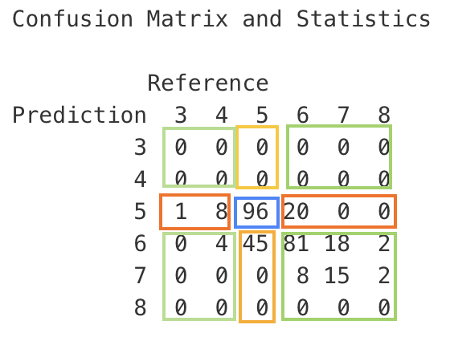

Se observa entonces que el modelo tiene una precision del 64%; valor que significa una buena cantida de aciertos en la categoria correcta

1. [Introduction to R markdown](https://rmarkdown.rstudio.com/articles_intro.html)
2. [MarkDown Guide - Basic Syntax](https://www.markdownguide.org/basic-syntax/)
3. [Data Visualization CheatSheet](https://github.com/rstudio/cheatsheets/blob/main/data-visualization.pdf)
4. [Repositorio del Taller en Github](https://github.com/aosoriom7/MER_AED_2025I)
5. [Pagina web del taller en Gihub Pages](https://aosoriom7.github.io/MER_AED_2025I/scripts/T04_Final_AEDatos.html)
6. [Arboles de decisión con R - Clasificación](https://rpubs.com/jboscomendoza/arboles_decision_clasificacion)
7. [Conjunto de Datos](https://www.kaggle.com/datasets/yasserh/wine-quality-dataset?resource=download)
8. [Programacion en R](https://rsanchezs.gitbooks.io/rprogramming/content/chapter9/dplyr.html)
9. [tidyverse](https://www.tidyverse.org/)
10. [Aprendizaje Supervisado en R](https://fervilber.github.io/Aprendizaje-supervisado-en-R/arboles.html)
11. [Comandos Basicos de la sintaxis de Markdown](https://rpubs.com/gustavomtzv/862622)
12. [Manual de Analisis Predictivo](https://rpubs.com/paraneda/predictivo)
13. [Package rpart](https://cran.r-project.org/web/packages/rpart/rpart.pdf)